# Section 3: Data Explanatory Analysis

Lan Nguyen (6687547) | Lisa Verlare (6929699) | Nguyen Thuy Duong (6827209)

# 1 Data Preparation (Lisa)

The first part of this data preparation section consists of preparations to join the data sets together for more efficient coding and several functions are used to clean up the data.

The second part of this section consists of a small amount of variable descriptions and will produce a table with all variables.

The third part of this section shows a small sample description and the fourth saves the separate data sets again, in order to easily find each year.

```r
# import the data sets from the data folder
year1999 <- read_dta("data/base99.dta")
year2000 <- read_dta("data/base00.dta")
year2001 <- read_dta("data/base01.dta")
year2002 <- read_dta("data/base02.dta")
```

```r
# Look at the data to see whether the data sets are tidy (i.e., one value in a
# cell) and does not need any adjustment in terms of needing to separate cells
# or columns
head(year1999)
```

```
## # A tibble: 6 × 25
##   treated  pair m_ahim   boy  ole5 educav educem zakaibag lagscore semrel
##     <dbl> <dbl>  <dbl> <dbl> <dbl>  <dbl>  <dbl>    <dbl>    <dbl>  <dbl>
## 1       1    17      1     1     0     12     12        0        0      0
## 2       0    13      5     1     0      6      6        0        0      0
## 3       0     5      1     1     0     18     15        0        0      0
## 4       1    19      4     1     0     10     11        0        0      0
## 5       1    16      3     1     0     10     11        0        0      0
## 6       1    11      2     1     0     12     11        0        0      0
## # … with 15 more variables: semarab <dbl>, att18 <dbl>, att20 <dbl>,
## #   att22 <dbl>, att24 <dbl>, awr18 <dbl>, awr20 <dbl>, awr22 <dbl>,
## #   awr24 <dbl>, achv_math <dbl>, achv_eng <dbl>, achv_hib <dbl>, year <dbl>,
## #   student_id <dbl>, school_id <dbl>
```

```r
head(year2000)
```

```
## # A tibble: 6 × 25
##   treated  pair m_ahim   boy  ole5 educav educem zakaibag lagscore semrel
##     <dbl> <dbl>  <dbl> <dbl> <dbl>  <dbl>  <dbl>    <dbl>    <dbl>  <dbl>
## 1       0    18      5     1     0      8      7        1     73.3      0
## 2       1     7      2     0     0      1      1        0      0        0
## 3       0    13      3     1     0     12     15        0      0        0
## 4       1     5      3     1     0      8      8        0     85.9      1
## 5       1    20      2     1     0      8      7        1     74        0
## 6       0    19      3     1     0     10     11        0      0        0
## # … with 15 more variables: semarab <dbl>, att18 <dbl>, att20 <dbl>,
## #   att22 <dbl>, att24 <dbl>, awr18 <dbl>, awr20 <dbl>, awr22 <dbl>,
## #   awr24 <dbl>, achv_math <dbl>, achv_eng <dbl>, achv_hib <dbl>, year <dbl>,
## #   student_id <dbl>, school_id <dbl>
```

```r
head(year2001)
```

```
## # A tibble: 6 × 25
##   treated  pair m_ahim   boy  ole5 educav educem zakaibag lagscore semrel
##     <dbl> <dbl>  <dbl> <dbl> <dbl>  <dbl>  <dbl>    <dbl>    <dbl>  <dbl>
## 1       0     5      1     1     0     23     18        0    100        0
## 2       1     8      2     1     0     10     16        0     68.2      0
## 3       1     5      5     1     0     11     11        1     63        1
## 4       1     7      8     1     0     10      8        0     44.9      1
## 5       1    10      2     0     0      3     11        0     76.9      0
## 6       0     9      1     0     0     18     17        0     75.8      0
## # … with 15 more variables: semarab <dbl>, att18 <dbl>, att20 <dbl>,
## #   att22 <dbl>, att24 <dbl>, awr18 <dbl>, awr20 <dbl>, awr22 <dbl>,
## #   awr24 <dbl>, achv_math <dbl>, achv_eng <dbl>, achv_hib <dbl>, year <dbl>,
## #   student_id <dbl>, school_id <dbl>
```

```r
head(year2002)
```

```
## # A tibble: 6 × 25
##   treated  pair m_ahim   boy  ole5 educav educem zakaibag lagscore semrel
##     <dbl> <dbl>  <dbl> <dbl> <dbl>  <dbl>  <dbl>    <dbl>    <dbl>  <dbl>
## 1       1     7      2     0     0      1      1        0      0        0
## 2       1     5      3     1     0     10     11        0     68.6      1
## 3       0    19      3     1     0     11     11        0     25        0
## 4       0     2      3     0     0     12     12        0      0        1
## 5       0     3      1     1     0      8     10        0      3        0
## 6       0    12      2     0     0     18     17        0      0        0
## # … with 15 more variables: semarab <dbl>, att18 <dbl>, att20 <dbl>,
## #   att22 <dbl>, att24 <dbl>, awr18 <dbl>, awr20 <dbl>, awr22 <dbl>,
## #   awr24 <dbl>, achv_math <dbl>, achv_eng <dbl>, achv_hib <dbl>, year <dbl>,
## #   student_id <dbl>, school_id <dbl>
```

```r
# Checking for missing values
sum(is.na(year1999))
```

```
## [1] 0
```

```r
sum(is.na(year2000))
```

```
## [1] 0
```

```r
sum(is.na(year2001))
```

```
## [1] 0
```

```r
sum(is.na(year2002))
```

```
## [1] 0
```

**Conclusion:**

```
* Each dataset has 25 columns

* Each dataset has one entry per column and rows are clearly observations for separate students

* Each dataset has 0 missing values.
```

Next, we merge the data sets in order to make some changes that are not specific to a year.

```r
# Check whether the columns are the same, otherwise adjustments will have to be
# made before they can be joined together
identical(colnames(year1999), colnames(year2000))
```

```
## [1] TRUE
```

```r
identical(colnames(year1999), colnames(year2001))
```

```
## [1] TRUE
```

```r
identical(colnames(year1999), colnames(year2002))
```

```
## [1] TRUE
```

Each data set has identical column names, which means that each data set has the same sort of observations. Hence, we can merge the data sets together.

```r
# Merging / Joining all data sets into one data set to make the
# cleaning up process easier
data <- full_join(year1999, year2000)
data <- full_join(data, year2001)
data <- full_join(data, year2002)
```

Now that the data sets are merged together, we can efficiently clean up the data set.

```r
# Renaming variables to make them more understandable
data <- data %>%
  rename(
    siblings = m_ahim,
    immigrant = ole5,
    father_educ = educav,
    mother_educ = educem,
    bagrut_status = zakaibag,
    school_religious = semrel,
    school_arab = semarab
  )
```

The `year` variable now indicates a date with ‘00’ instead of 2000. Otherwise, it could be confusing when filtering.

```r
# Naming year entries according to their full year, which will make it easier
# to filter out years and make them more understandable
data <- data %>%
  mutate(
    year = replace(year, year == 99, 1999),
    year = replace(year, year == 0, 2000),
    year = replace(year, year == 1, 2001),
    year = replace(year, year == 2, 2002)
    )
```

The authors have also coded additional variables.

```r
# Adding and removing variables for the replication process

data <- data %>%
   mutate(
      # at least 4 siblings dummy
      siblings_4 = as.numeric(siblings >= 4),

      # Categorizing pair and school_id as a factor
      pair = as.factor(pair),
      school_id = as.factor(school_id)
      ) %>%

  # removing variables we will not be using in our research
  select(
    -student_id, -att18, -att20, -att22, -att24, -awr18, -awr20, -awr22, -awr24,
    -achv_math, -achv_eng, -achv_hib
    )
```

This variable is for our own analysis.

```r
# Creating a siblings variable into a categorical variable
data$sib_category <- as.factor(
  ifelse(data$siblings == 1, "1",
         ifelse(data$siblings == 2, "2",
                ifelse(data$siblings == 3, "3",
                       ifelse(data$siblings == 4, "4", "4+"
                              )
                       )
                )
         )
  )
```

We now separate the data sets again, to make individual variables per year.

```r
# Saving the final data, in case we will use another Rmd file or for any other
# purpose
saveRDS(data, file = "data/full_data.Rdata")

# splitting up the datasets again per year and saving them to  use in other Rmd
# files
data_1999 <- data %>%
  filter(year == 1999)

data_2000 <- data %>%
  filter(year == 2000)

data_2001 <- data %>%
  filter(year == 2001)

data_2002 <- data %>%
  filter(year == 2002)
```

```r
# create quantile dummies for 1999
data_1999 <- data_1999 %>%
  mutate(

    # quartiles
    ls_100 = as.numeric(lagscore >= quantile(lagscore, 0.75)),
    ls_75 = as.numeric(
      lagscore >= quantile(lagscore, 0.50) &
        lagscore < quantile(lagscore, 0.75)
      ),
    ls_50 = as.numeric(
      lagscore >= quantile(lagscore, 0.25) &
        lagscore < quantile(lagscore, 0.50)
      ),
    ls_25 =  as.numeric(lagscore < quantile(lagscore, 0.25)),

    # top and bottom marginal groups
    top_ls = ifelse(ls_75 == 1 | ls_100 == 1, 1, 0),
    bot_ls = ifelse(ls_25 == 1 | ls_50 == 1, 1, 0),

    # lagged score
    ls = lagscore
    )

# create quantile dummies for 2000
data_2000 <- data_2000 %>%
  mutate(

    # quartiles
    ls_100 = as.numeric(lagscore >= quantile(lagscore, 0.75)),
    ls_75 = as.numeric(
      lagscore >= quantile(lagscore, 0.50) &
        lagscore < quantile(lagscore, 0.75)
      ),
    ls_50 = as.numeric(
      lagscore >= quantile(lagscore, 0.25) &
        lagscore < quantile(lagscore, 0.50)
      ),
    ls_25 =  as.numeric(lagscore < quantile(lagscore, 0.25)),

    # top and bottom marginal groups
    top_ls = ifelse(ls_75 == 1 | ls_100 == 1, 1, 0),
    bot_ls = ifelse(ls_25 == 1 | ls_50 == 1, 1, 0),

    # lagged score
    ls = lagscore
    )

# create quantile, marginal top and bottom dummies for 2001
data_2001 <- data_2001 %>%
  mutate(

    # quartiles
    ls_100 = as.numeric(lagscore >= quantile(lagscore, 0.75)),
    ls_75 = as.numeric(
      lagscore >= quantile(lagscore, 0.50) &
        lagscore < quantile(lagscore, 0.75)
      ),
    ls_50 = as.numeric(
      lagscore >= quantile(lagscore, 0.25) &
        lagscore < quantile(lagscore, 0.50)
      ),
    ls_25 =  as.numeric(lagscore < quantile(lagscore, 0.25)),

    # top and bottom marginal groups
    top_ls = ifelse(ls_75 == 1 | ls_100 == 1, 1, 0),
    bot_ls = ifelse(ls_25 == 1 | ls_50 == 1, 1, 0),

    # lagged score
    ls = lagscore
         )

# create quantile, marginal top and bottom dummies for 2002
data_2002 <- data_2002 %>%
  mutate(

    # quartiles
    ls_100 = as.numeric(lagscore >= quantile(lagscore, 0.75)),
    ls_75 = as.numeric(
      lagscore >= quantile(lagscore, 0.50) &
        lagscore < quantile(lagscore, 0.75)
      ),
    ls_50 = as.numeric(
      lagscore >= quantile(lagscore, 0.25) &
        lagscore < quantile(lagscore, 0.50)
      ),
    ls_25 =  as.numeric(lagscore < quantile(lagscore, 0.25)),

    # top and bottom marginal groups
    top_ls = ifelse(ls_75 == 1 | ls_100 == 1, 1, 0),
    bot_ls = ifelse(ls_25 == 1 | ls_50 == 1, 1, 0),

    # lagged score
    ls = lagscore
         )
```

We will save the data sets in the folder *data*, because we have separated our code into multiple Rmd files. This will make it easy to access.

```r
# saving the data sets
saveRDS(data_1999, file = "data/data_1999.Rda")
saveRDS(data_2000, file = "data/data_2000.Rda")
saveRDS(data_2001, file = "data/data_2001.Rda")
saveRDS(data_2002, file = "data/data_2002.Rda")
```

## 1.1 Variable Description (Lisa)

In this part we show a small variable description and generate a *Variable Description Table* that will be included in the paper. We look at the data in general, as this is in regards to variables, not years.

```r
# Check what the class of each variable is
lapply(data, class)
```

```
## $treated
## [1] "numeric"
##
## $pair
## [1] "factor"
##
## $siblings
## [1] "numeric"
##
## $boy
## [1] "numeric"
##
## $immigrant
## [1] "numeric"
##
## $father_educ
## [1] "numeric"
##
## $mother_educ
## [1] "numeric"
##
## $bagrut_status
## [1] "numeric"
##
## $lagscore
## [1] "numeric"
##
## $school_religious
## [1] "numeric"
##
## $school_arab
## [1] "numeric"
##
## $year
## [1] "numeric"
##
## $school_id
## [1] "factor"
##
## $siblings_4
## [1] "numeric"
##
## $sib_category
## [1] "factor"
```

```r
# Check whether those we suspect to be dummies are actually dummies
summary(data)
```

```
##     treated            pair         siblings           boy
##  Min.   :0.0000   18     :1508   Min.   : 1.000   Min.   :0.0000
##  1st Qu.:0.0000   2      :1317   1st Qu.: 2.000   1st Qu.:0.0000
##  Median :1.0000   15     :1276   Median : 3.000   Median :1.0000
##  Mean   :0.5018   4      :1248   Mean   : 3.704   Mean   :0.5101
##  3rd Qu.:1.0000   20     :1218   3rd Qu.: 5.000   3rd Qu.:1.0000
##  Max.   :1.0000   11     :1185   Max.   :22.000   Max.   :1.0000
##                   (Other):8774
##    immigrant        father_educ     mother_educ     bagrut_status
##  Min.   :0.00000   Min.   : 1.00   Min.   : 1.000   Min.   :0.000
##  1st Qu.:0.00000   1st Qu.: 8.00   1st Qu.: 8.000   1st Qu.:0.000
##  Median :0.00000   Median :10.00   Median :10.000   Median :0.000
##  Mean   :0.07885   Mean   :10.08   Mean   : 9.959   Mean   :0.256
##  3rd Qu.:0.00000   3rd Qu.:12.00   3rd Qu.:12.000   3rd Qu.:1.000
##  Max.   :1.00000   Max.   :25.00   Max.   :25.000   Max.   :1.000
##
##     lagscore     school_religious  school_arab          year
##  Min.   :  0.0   Min.   :0.0000   Min.   :0.0000   Min.   :1999
##  1st Qu.:  0.0   1st Qu.:0.0000   1st Qu.:0.0000   1st Qu.:1999
##  Median : 47.5   Median :0.0000   Median :0.0000   Median :2000
##  Mean   : 38.4   Mean   :0.1202   Mean   :0.3356   Mean   :2000
##  3rd Qu.: 69.5   3rd Qu.:0.0000   3rd Qu.:1.0000   3rd Qu.:2002
##  Max.   :100.0   Max.   :1.0000   Max.   :1.0000   Max.   :2002
##
##    school_id       siblings_4     sib_category
##  25     :  959   Min.   :0.0000   1 :2494
##  6      :  906   1st Qu.:0.0000   2 :4399
##  19     :  766   Median :0.0000   3 :2641
##  12     :  750   Mean   :0.4231   4 :2170
##  8      :  674   3rd Qu.:1.0000   4+:4822
##  17     :  669   Max.   :1.0000
##  (Other):11802
```

**Conclusion:**

```
* There are 12 variables that are numeric, of which 7 are binary dummies.
* There are 3 variables that are factors
```

**Disclaimer:** The following table describes the data in general, not per year.

```r
# input for the variable description table
text_tbl <- data.frame(
  Variables = c(
    "treated", "pair", "siblings", "boy", "immigrant", "father_educ",
    "mother_educ", "bagrut_status", "lagscore", "school_religious",
    "school_arab", "year", "ls_#", "siblings_4", "sib_group"
    ),

  Description = c(
    "Treatment indicator, i.e., treated (1) and treatment (0)",
    "Treatment pair. Each treated school is paired to an untreated school that
    are most similar in characteristics.",
    "Number of siblings",
    "Gender indicator, i.e., boy (1) and girl (0)",
    "Immigrant indicator, i.e., immigrant (1) and non-immigrant (0)",
    "Father’s years of schooling",
    "Mother’s years of schooling",
    "Bagrut status, i.e., Bagrut (1) and no Bagrut (0)",
    "Lagged Bagrut score, based on Bagrut rates from 1999",
    "Indicator of Jewish religious school, i.e., Jewish religious (1) and
    non-Jewish religious (0)",
    "Indicator of Arab school, i.e., Arab (1) and non-Arab (0)",
    "Year indicator",
    "Indicators of quantiles (25, 50, 75, 100), i.e., quantile (1) and not in
    the quantile (0)",
    "Indicator whether the individual has 4 or more siblings, i.e. 4(+) siblings
    (1) and less than 4 siblings (0)",
    "Categorical variable for the amount of siblings, ranging from 1-4+"
    )
)

# Creating the table
kbl(text_tbl, caption = "<b>Table 1: Variable Descripton</b>") %>%
  kable_classic(full_width = FALSE, html_font = "Times New Roman") %>%
  kable_styling(bootstrap_options = c("bordered", "basic")) %>%
  row_spec(0, bold = TRUE) %>%
  column_spec(1, bold = FALSE, border_right = TRUE, background = "lightgrey") %>%
  column_spec(2, width = "16cm") %>%
  footnote(
    general = c(
      "The table describes the variables in general, they are not year specific"
      ),
    footnote_as_chunk = T
  )
```

**Table 1: Variable Descripton**

[output not shown]

Note: The table describes the variables in general, they are not year specific

# 2 Data Descriptives (Duong)

## 2.1 Replication Table 1

### 2.1.1 Administrative Dataset

```r
# All variables in the Experimental sample
summary(data)
```

```
##     treated            pair         siblings           boy
##  Min.   :0.0000   18     :1508   Min.   : 1.000   Min.   :0.0000
##  1st Qu.:0.0000   2      :1317   1st Qu.: 2.000   1st Qu.:0.0000
##  Median :1.0000   15     :1276   Median : 3.000   Median :1.0000
##  Mean   :0.5018   4      :1248   Mean   : 3.704   Mean   :0.5101
##  3rd Qu.:1.0000   20     :1218   3rd Qu.: 5.000   3rd Qu.:1.0000
##  Max.   :1.0000   11     :1185   Max.   :22.000   Max.   :1.0000
##                   (Other):8774
##    immigrant        father_educ     mother_educ     bagrut_status
##  Min.   :0.00000   Min.   : 1.00   Min.   : 1.000   Min.   :0.000
##  1st Qu.:0.00000   1st Qu.: 8.00   1st Qu.: 8.000   1st Qu.:0.000
##  Median :0.00000   Median :10.00   Median :10.000   Median :0.000
##  Mean   :0.07885   Mean   :10.08   Mean   : 9.959   Mean   :0.256
##  3rd Qu.:0.00000   3rd Qu.:12.00   3rd Qu.:12.000   3rd Qu.:1.000
##  Max.   :1.00000   Max.   :25.00   Max.   :25.000   Max.   :1.000
##
##     lagscore     school_religious  school_arab          year
##  Min.   :  0.0   Min.   :0.0000   Min.   :0.0000   Min.   :1999
##  1st Qu.:  0.0   1st Qu.:0.0000   1st Qu.:0.0000   1st Qu.:1999
##  Median : 47.5   Median :0.0000   Median :0.0000   Median :2000
##  Mean   : 38.4   Mean   :0.1202   Mean   :0.3356   Mean   :2000
##  3rd Qu.: 69.5   3rd Qu.:0.0000   3rd Qu.:1.0000   3rd Qu.:2002
##  Max.   :100.0   Max.   :1.0000   Max.   :1.0000   Max.   :2002
##
##    school_id       siblings_4     sib_category
##  25     :  959   Min.   :0.0000   1 :2494
##  6      :  906   1st Qu.:0.0000   2 :4399
##  19     :  766   Median :0.0000   3 :2641
##  12     :  750   Mean   :0.4231   4 :2170
##  8      :  674   3rd Qu.:1.0000   4+:4822
##  17     :  669   Max.   :1.0000
##  (Other):11802
```

### 2.1.2 Panel A.2001

```r
# All variables in the treated year 2001 sample
summary(data_2001)
```

```
##     treated           pair         siblings           boy
##  Min.   :0.000   18     : 329   Min.   : 1.000   Min.   :0.000
##  1st Qu.:0.000   4      : 321   1st Qu.: 2.000   1st Qu.:0.000
##  Median :1.000   15     : 315   Median : 3.000   Median :1.000
##  Mean   :0.509   2      : 292   Mean   : 3.742   Mean   :0.513
##  3rd Qu.:1.000   11     : 286   3rd Qu.: 5.000   3rd Qu.:1.000
##  Max.   :1.000   20     : 278   Max.   :21.000   Max.   :1.000
##                  (Other):2000
##    immigrant       father_educ     mother_educ    bagrut_status
##  Min.   :0.0000   Min.   : 1.00   Min.   : 1.00   Min.   :0.0000
##  1st Qu.:0.0000   1st Qu.: 8.00   1st Qu.: 8.00   1st Qu.:0.0000
##  Median :0.0000   Median :10.00   Median :11.00   Median :0.0000
##  Mean   :0.0636   Mean   :10.07   Mean   :10.02   Mean   :0.2426
##  3rd Qu.:0.0000   3rd Qu.:12.00   3rd Qu.:12.00   3rd Qu.:0.0000
##  Max.   :1.0000   Max.   :25.00   Max.   :25.00   Max.   :1.0000
##
##     lagscore      school_religious  school_arab          year
##  Min.   :  0.00   Min.   :0.0000   Min.   :0.0000   Min.   :2001
##  1st Qu.: 39.33   1st Qu.:0.0000   1st Qu.:0.0000   1st Qu.:2001
##  Median : 62.00   Median :0.0000   Median :0.0000   Median :2001
##  Mean   : 53.12   Mean   :0.1152   Mean   :0.3481   Mean   :2001
##  3rd Qu.: 74.83   3rd Qu.:0.0000   3rd Qu.:1.0000   3rd Qu.:2001
##  Max.   :100.00   Max.   :1.0000   Max.   :1.0000   Max.   :2001
##
##    school_id      siblings_4     sib_category     ls_100           ls_75
##  25     : 248   Min.   :0.0000   1 : 578      Min.   :0.0000   Min.   :0.0000
##  6      : 219   1st Qu.:0.0000   2 :1029      1st Qu.:0.0000   1st Qu.:0.0000
##  19     : 185   Median :0.0000   3 : 606      Median :0.0000   Median :0.0000
##  12     : 175   Mean   :0.4208   4 : 480      Mean   :0.2505   Mean   :0.2536
##  34     : 167   3rd Qu.:1.0000   4+:1128      3rd Qu.:1.0000   3rd Qu.:1.0000
##  8      : 163   Max.   :1.0000                Max.   :1.0000   Max.   :1.0000
##  (Other):2664
##      ls_50           ls_25            top_ls           bot_ls
##  Min.   :0.000   Min.   :0.0000   Min.   :0.0000   Min.   :0.0000
##  1st Qu.:0.000   1st Qu.:0.0000   1st Qu.:0.0000   1st Qu.:0.0000
##  Median :0.000   Median :0.0000   Median :1.0000   Median :0.0000
##  Mean   :0.246   Mean   :0.2499   Mean   :0.5041   Mean   :0.4959
##  3rd Qu.:0.000   3rd Qu.:0.0000   3rd Qu.:1.0000   3rd Qu.:1.0000
##  Max.   :1.000   Max.   :1.0000   Max.   :1.0000   Max.   :1.0000
##
##        ls
##  Min.   :  0.00
##  1st Qu.: 39.33
##  Median : 62.00
##  Mean   : 53.12
##  3rd Qu.: 74.83
##  Max.   :100.00
##
```

```r
# Subset samples
  # Subset for boys
summary(subset(data_2001, boy == 1))
```

```
##     treated            pair         siblings           boy      immigrant
##  Min.   :0.0000   1      : 174   Min.   : 1.000   Min.   :1   Min.   :0.00000
##  1st Qu.:0.0000   4      : 162   1st Qu.: 2.000   1st Qu.:1   1st Qu.:0.00000
##  Median :1.0000   18     : 158   Median : 3.000   Median :1   Median :0.00000
##  Mean   :0.5663   15     : 157   Mean   : 3.651   Mean   :1   Mean   :0.02857
##  3rd Qu.:1.0000   20     : 146   3rd Qu.: 5.000   3rd Qu.:1   3rd Qu.:0.00000
##  Max.   :1.0000   11     : 145   Max.   :20.000   Max.   :1   Max.   :1.00000
##                   (Other):1018
##   father_educ      mother_educ     bagrut_status    lagscore
##  Min.   : 1.000   Min.   : 1.000   Min.   :0.0   Min.   :  0.00
##  1st Qu.: 8.000   1st Qu.: 8.000   1st Qu.:0.0   1st Qu.: 37.50
##  Median :10.000   Median :11.000   Median :0.0   Median : 60.42
##  Mean   : 9.819   Mean   : 9.867   Mean   :0.2   Mean   : 52.06
##  3rd Qu.:12.000   3rd Qu.:12.000   3rd Qu.:0.0   3rd Qu.: 74.00
##  Max.   :23.000   Max.   :25.000   Max.   :1.0   Max.   :100.00
##
##  school_religious   school_arab          year        school_id
##  Min.   :0.00000   Min.   :0.0000   Min.   :2001   12     : 141
##  1st Qu.:0.00000   1st Qu.:0.0000   1st Qu.:2001   25     : 118
##  Median :0.00000   Median :0.0000   Median :2001   34     : 103
##  Mean   :0.08418   Mean   :0.3745   Mean   :2001   17     : 100
##  3rd Qu.:0.00000   3rd Qu.:1.0000   3rd Qu.:2001   6      :  95
##  Max.   :1.00000   Max.   :1.0000   Max.   :2001   2      :  91
##                                                    (Other):1312
##    siblings_4     sib_category     ls_100           ls_75
##  Min.   :0.0000   1 :300       Min.   :0.0000   Min.   :0.0000
##  1st Qu.:0.0000   2 :553       1st Qu.:0.0000   1st Qu.:0.0000
##  Median :0.0000   3 :307       Median :0.0000   Median :0.0000
##  Mean   :0.4082   4 :257       Mean   :0.2321   Mean   :0.2449
##  3rd Qu.:1.0000   4+:543       3rd Qu.:0.0000   3rd Qu.:0.0000
##  Max.   :1.0000                Max.   :1.0000   Max.   :1.0000
##
##      ls_50            ls_25            top_ls          bot_ls
##  Min.   :0.0000   Min.   :0.0000   Min.   :0.000   Min.   :0.000
##  1st Qu.:0.0000   1st Qu.:0.0000   1st Qu.:0.000   1st Qu.:0.000
##  Median :0.0000   Median :0.0000   Median :0.000   Median :1.000
##  Mean   :0.2628   Mean   :0.2602   Mean   :0.477   Mean   :0.523
##  3rd Qu.:1.0000   3rd Qu.:1.0000   3rd Qu.:1.000   3rd Qu.:1.000
##  Max.   :1.0000   Max.   :1.0000   Max.   :1.000   Max.   :1.000
##
##        ls
##  Min.   :  0.00
##  1st Qu.: 37.50
##  Median : 60.42
##  Mean   : 52.06
##  3rd Qu.: 74.00
##  Max.   :100.00
##
```

```r
  # Subset for girls
summary(subset(data_2001, boy == 0))
```

```
##     treated            pair        siblings           boy      immigrant
##  Min.   :0.0000   2      :191   Min.   : 1.000   Min.   :0   Min.   :0.0000
##  1st Qu.:0.0000   18     :171   1st Qu.: 2.000   1st Qu.:0   1st Qu.:0.0000
##  Median :0.0000   4      :159   Median : 3.000   Median :0   Median :0.0000
##  Mean   :0.4487   15     :158   Mean   : 3.839   Mean   :0   Mean   :0.1005
##  3rd Qu.:1.0000   14     :148   3rd Qu.: 5.000   3rd Qu.:0   3rd Qu.:0.0000
##  Max.   :1.0000   11     :141   Max.   :21.000   Max.   :0   Max.   :1.0000
##                   (Other):893
##   father_educ     mother_educ    bagrut_status       lagscore
##  Min.   : 1.00   Min.   : 1.00   Min.   :0.0000   Min.   :  0.00
##  1st Qu.: 8.00   1st Qu.: 8.00   1st Qu.:0.0000   1st Qu.: 41.33
##  Median :10.00   Median :11.00   Median :0.0000   Median : 63.67
##  Mean   :10.33   Mean   :10.18   Mean   :0.2875   Mean   : 54.23
##  3rd Qu.:12.00   3rd Qu.:12.00   3rd Qu.:1.0000   3rd Qu.: 75.57
##  Max.   :25.00   Max.   :25.00   Max.   :1.0000   Max.   :100.00
##
##  school_religious  school_arab          year        school_id
##  Min.   :0.0000   Min.   :0.0000   Min.   :2001   1      : 146
##  1st Qu.:0.0000   1st Qu.:0.0000   1st Qu.:2001   25     : 130
##  Median :0.0000   Median :0.0000   Median :2001   6      : 124
##  Mean   :0.1478   Mean   :0.3203   Mean   :2001   19     : 103
##  3rd Qu.:0.0000   3rd Qu.:1.0000   3rd Qu.:2001   35     :  83
##  Max.   :1.0000   Max.   :1.0000   Max.   :2001   10     :  80
##                                                   (Other):1195
##    siblings_4     sib_category     ls_100           ls_75
##  Min.   :0.0000   1 :278       Min.   :0.0000   Min.   :0.0000
##  1st Qu.:0.0000   2 :476       1st Qu.:0.0000   1st Qu.:0.0000
##  Median :0.0000   3 :299       Median :0.0000   Median :0.0000
##  Mean   :0.4342   4 :223       Mean   :0.2697   Mean   :0.2628
##  3rd Qu.:1.0000   4+:585       3rd Qu.:1.0000   3rd Qu.:1.0000
##  Max.   :1.0000                Max.   :1.0000   Max.   :1.0000
##
##      ls_50            ls_25            top_ls           bot_ls
##  Min.   :0.0000   Min.   :0.0000   Min.   :0.0000   Min.   :0.0000
##  1st Qu.:0.0000   1st Qu.:0.0000   1st Qu.:0.0000   1st Qu.:0.0000
##  Median :0.0000   Median :0.0000   Median :1.0000   Median :0.0000
##  Mean   :0.2284   Mean   :0.2391   Mean   :0.5325   Mean   :0.4675
##  3rd Qu.:0.0000   3rd Qu.:0.0000   3rd Qu.:1.0000   3rd Qu.:1.0000
##  Max.   :1.0000   Max.   :1.0000   Max.   :1.0000   Max.   :1.0000
##
##        ls
##  Min.   :  0.00
##  1st Qu.: 41.33
##  Median : 63.67
##  Mean   : 54.23
##  3rd Qu.: 75.57
##  Max.   :100.00
##
```

```r
# Comparing statistics of key variables in full sample and 2001 sample

list("siblings" = summary(data$siblings),
     "siblings_2001" = summary(data_2001$siblings),
     "father_educ" = summary(data$father_educ),
     "father_educ_2001" = summary(data_2001$father_educ),
     "mother_educ_2001" = summary(data_2001$mother_educ),
     "mother_educ" = summary(data$mother_educ))
```

```
## $siblings
##    Min. 1st Qu.  Median    Mean 3rd Qu.    Max.
##   1.000   2.000   3.000   3.704   5.000  22.000
##
## $siblings_2001
##    Min. 1st Qu.  Median    Mean 3rd Qu.    Max.
##   1.000   2.000   3.000   3.742   5.000  21.000
##
## $father_educ
##    Min. 1st Qu.  Median    Mean 3rd Qu.    Max.
##    1.00    8.00   10.00   10.08   12.00   25.00
##
## $father_educ_2001
##    Min. 1st Qu.  Median    Mean 3rd Qu.    Max.
##    1.00    8.00   10.00   10.07   12.00   25.00
##
## $mother_educ_2001
##    Min. 1st Qu.  Median    Mean 3rd Qu.    Max.
##    1.00    8.00   11.00   10.02   12.00   25.00
##
## $mother_educ
##    Min. 1st Qu.  Median    Mean 3rd Qu.    Max.
##   1.000   8.000  10.000   9.959  12.000  25.000
```

### 2.1.3 Panel B.2000

```r
# All variables in the control year 2000 sample
summary(data_2000)
```

```
##     treated            pair         siblings           boy
##  Min.   :0.0000   18     : 359   Min.   : 1.000   Min.   :0.0000
##  1st Qu.:0.0000   2      : 355   1st Qu.: 2.000   1st Qu.:0.0000
##  Median :1.0000   11     : 306   Median : 3.000   Median :1.0000
##  Mean   :0.5014   20     : 305   Mean   : 3.682   Mean   :0.5046
##  3rd Qu.:1.0000   15     : 294   3rd Qu.: 5.000   3rd Qu.:1.0000
##  Max.   :1.0000   4      : 291   Max.   :19.000   Max.   :1.0000
##                   (Other):2129
##    immigrant        father_educ      mother_educ     bagrut_status
##  Min.   :0.00000   Min.   : 1.000   Min.   : 1.000   Min.   :0.0000
##  1st Qu.:0.00000   1st Qu.: 8.000   1st Qu.: 8.000   1st Qu.:0.0000
##  Median :0.00000   Median :10.000   Median :10.000   Median :0.0000
##  Mean   :0.07378   Mean   : 9.871   Mean   : 9.798   Mean   :0.2243
##  3rd Qu.:0.00000   3rd Qu.:12.000   3rd Qu.:12.000   3rd Qu.:0.0000
##  Max.   :1.00000   Max.   :25.000   Max.   :22.000   Max.   :1.0000
##
##     lagscore      school_religious  school_arab          year
##  Min.   :  0.00   Min.   :0.0000   Min.   :0.0000   Min.   :2000
##  1st Qu.: 34.10   1st Qu.:0.0000   1st Qu.:0.0000   1st Qu.:2000
##  Median : 59.43   Median :0.0000   Median :0.0000   Median :2000
##  Mean   : 50.23   Mean   :0.1337   Mean   :0.3194   Mean   :2000
##  3rd Qu.: 71.82   3rd Qu.:0.0000   3rd Qu.:1.0000   3rd Qu.:2000
##  Max.   :100.00   Max.   :1.0000   Max.   :1.0000   Max.   :2000
##
##    school_id      siblings_4     sib_category     ls_100           ls_75
##  25     : 223   Min.   :0.0000   1 : 612      Min.   :0.0000   Min.   :0.0000
##  6      : 211   1st Qu.:0.0000   2 :1017      1st Qu.:0.0000   1st Qu.:0.0000
##  17     : 185   Median :0.0000   3 : 671      Median :0.0000   Median :0.0000
##  12     : 173   Mean   :0.4306   4 : 552      Mean   :0.2501   Mean   :0.2501
##  1      : 170   3rd Qu.:1.0000   4+:1187      3rd Qu.:0.5000   3rd Qu.:0.5000
##  19     : 170   Max.   :1.0000                Max.   :1.0000   Max.   :1.0000
##  (Other):2907
##      ls_50            ls_25            top_ls           bot_ls
##  Min.   :0.0000   Min.   :0.0000   Min.   :0.0000   Min.   :0.0000
##  1st Qu.:0.0000   1st Qu.:0.0000   1st Qu.:0.0000   1st Qu.:0.0000
##  Median :0.0000   Median :0.0000   Median :1.0000   Median :0.0000
##  Mean   :0.2498   Mean   :0.2501   Mean   :0.5001   Mean   :0.4999
##  3rd Qu.:0.0000   3rd Qu.:0.5000   3rd Qu.:1.0000   3rd Qu.:1.0000
##  Max.   :1.0000   Max.   :1.0000   Max.   :1.0000   Max.   :1.0000
##
##        ls
##  Min.   :  0.00
##  1st Qu.: 34.10
##  Median : 59.43
##  Mean   : 50.23
##  3rd Qu.: 71.82
##  Max.   :100.00
##
```

```r
# Subset samples
  # Subset for boys
summary(subset(data_2000, boy == 1))
```

```
##     treated            pair         siblings           boy      immigrant
##  Min.   :0.0000   18     : 178   Min.   : 1.000   Min.   :1   Min.   :0.00000
##  1st Qu.:0.0000   1      : 169   1st Qu.: 2.000   1st Qu.:1   1st Qu.:0.00000
##  Median :1.0000   4      : 147   Median : 3.000   Median :1   Median :0.00000
##  Mean   :0.5643   11     : 145   Mean   : 3.531   Mean   :1   Mean   :0.03925
##  3rd Qu.:1.0000   15     : 135   3rd Qu.: 5.000   3rd Qu.:1   3rd Qu.:0.00000
##  Max.   :1.0000   20     : 133   Max.   :19.000   Max.   :1   Max.   :1.00000
##                   (Other):1131
##   father_educ      mother_educ     bagrut_status       lagscore
##  Min.   : 1.000   Min.   : 1.000   Min.   :0.0000   Min.   :  0.00
##  1st Qu.: 8.000   1st Qu.: 8.000   1st Qu.:0.0000   1st Qu.: 30.00
##  Median :10.000   Median :10.000   Median :0.0000   Median : 58.67
##  Mean   : 9.749   Mean   : 9.705   Mean   :0.1771   Mean   : 49.13
##  3rd Qu.:12.000   3rd Qu.:12.000   3rd Qu.:0.0000   3rd Qu.: 71.26
##  Max.   :25.000   Max.   :21.000   Max.   :1.0000   Max.   :100.00
##
##  school_religious   school_arab          year        school_id
##  Min.   :0.00000   Min.   :0.0000   Min.   :2000   12     : 142
##  1st Qu.:0.00000   1st Qu.:0.0000   1st Qu.:2000   17     : 121
##  Median :0.00000   Median :0.0000   Median :2000   25     : 111
##  Mean   :0.09814   Mean   :0.3518   Mean   :2000   6      :  98
##  3rd Qu.:0.00000   3rd Qu.:1.0000   3rd Qu.:2000   2      :  90
##  Max.   :1.00000   Max.   :1.0000   Max.   :2000   36     :  88
##                                                    (Other):1388
##    siblings_4     sib_category     ls_100           ls_75
##  Min.   :0.0000   1 :305       Min.   :0.0000   Min.   :0.0000
##  1st Qu.:0.0000   2 :552       1st Qu.:0.0000   1st Qu.:0.0000
##  Median :0.0000   3 :350       Median :0.0000   Median :0.0000
##  Mean   :0.4078   4 :286       Mean   :0.2399   Mean   :0.2502
##  3rd Qu.:1.0000   4+:545       3rd Qu.:0.0000   3rd Qu.:0.7500
##  Max.   :1.0000                Max.   :1.0000   Max.   :1.0000
##
##      ls_50            ls_25            top_ls           bot_ls
##  Min.   :0.0000   Min.   :0.0000   Min.   :0.0000   Min.   :0.0000
##  1st Qu.:0.0000   1st Qu.:0.0000   1st Qu.:0.0000   1st Qu.:0.0000
##  Median :0.0000   Median :0.0000   Median :0.0000   Median :1.0000
##  Mean   :0.2444   Mean   :0.2655   Mean   :0.4902   Mean   :0.5098
##  3rd Qu.:0.0000   3rd Qu.:1.0000   3rd Qu.:1.0000   3rd Qu.:1.0000
##  Max.   :1.0000   Max.   :1.0000   Max.   :1.0000   Max.   :1.0000
##
##        ls
##  Min.   :  0.00
##  1st Qu.: 30.00
##  Median : 58.67
##  Mean   : 49.13
##  3rd Qu.: 71.26
##  Max.   :100.00
##
```

```r
  # Subset for girls
summary(subset(data_2000, boy == 0))
```

```
##     treated            pair        siblings           boy      immigrant
##  Min.   :0.0000   2      :234   Min.   : 1.000   Min.   :0   Min.   :0.0000
##  1st Qu.:0.0000   18     :181   1st Qu.: 2.000   1st Qu.:0   1st Qu.:0.0000
##  Median :0.0000   20     :172   Median : 3.000   Median :0   Median :0.0000
##  Mean   :0.4373   11     :161   Mean   : 3.837   Mean   :0   Mean   :0.1089
##  3rd Qu.:1.0000   15     :159   3rd Qu.: 5.000   3rd Qu.:0   3rd Qu.:0.0000
##  Max.   :1.0000   4      :144   Max.   :19.000   Max.   :0   Max.   :1.0000
##                   (Other):950
##   father_educ      mother_educ     bagrut_status       lagscore
##  Min.   : 1.000   Min.   : 1.000   Min.   :0.0000   Min.   :  0.00
##  1st Qu.: 8.000   1st Qu.: 8.000   1st Qu.:0.0000   1st Qu.: 37.00
##  Median :10.000   Median :10.000   Median :0.0000   Median : 60.00
##  Mean   : 9.995   Mean   : 9.893   Mean   :0.2724   Mean   : 51.36
##  3rd Qu.:12.000   3rd Qu.:12.000   3rd Qu.:1.0000   3rd Qu.: 72.50
##  Max.   :25.000   Max.   :22.000   Max.   :1.0000   Max.   :100.00
##
##  school_religious  school_arab          year        school_id
##  Min.   :0.0000   Min.   :0.0000   Min.   :2000   1      : 170
##  1st Qu.:0.0000   1st Qu.:0.0000   1st Qu.:2000   30     : 114
##  Median :0.0000   Median :0.0000   Median :2000   6      : 113
##  Mean   :0.1699   Mean   :0.2864   Mean   :2000   25     : 112
##  3rd Qu.:0.0000   3rd Qu.:1.0000   3rd Qu.:2000   19     : 101
##  Max.   :1.0000   Max.   :1.0000   Max.   :2000   23     :  93
##                                                   (Other):1298
##    siblings_4     sib_category     ls_100           ls_75
##  Min.   :0.0000   1 :307       Min.   :0.0000   Min.   :0.0000
##  1st Qu.:0.0000   2 :465       1st Qu.:0.0000   1st Qu.:0.0000
##  Median :0.0000   3 :321       Median :0.0000   Median :0.0000
##  Mean   :0.4538   4 :266       Mean   :0.2604   Mean   :0.2499
##  3rd Qu.:1.0000   4+:642       3rd Qu.:1.0000   3rd Qu.:0.0000
##  Max.   :1.0000                Max.   :1.0000   Max.   :1.0000
##
##      ls_50            ls_25            top_ls           bot_ls
##  Min.   :0.0000   Min.   :0.0000   Min.   :0.0000   Min.   :0.0000
##  1st Qu.:0.0000   1st Qu.:0.0000   1st Qu.:0.0000   1st Qu.:0.0000
##  Median :0.0000   Median :0.0000   Median :1.0000   Median :0.0000
##  Mean   :0.2554   Mean   :0.2344   Mean   :0.5102   Mean   :0.4898
##  3rd Qu.:1.0000   3rd Qu.:0.0000   3rd Qu.:1.0000   3rd Qu.:1.0000
##  Max.   :1.0000   Max.   :1.0000   Max.   :1.0000   Max.   :1.0000
##
##        ls
##  Min.   :  0.00
##  1st Qu.: 37.00
##  Median : 60.00
##  Mean   : 51.36
##  3rd Qu.: 72.50
##  Max.   :100.00
##
```

```r
# Comparing statistics of key variables in full sample and 2000 sample

list("siblings" = summary(data$siblings),
     "siblings_2000" = summary(data_2000$siblings),
     "father_educ" = summary(data$father_educ),
     "father_educ_2000" = summary(data_2000$father_educ),
     "mother_educ_2000" = summary(data_2000$mother_educ),
     "mother_educ" = summary(data$mother_educ))
```

```
## $siblings
##    Min. 1st Qu.  Median    Mean 3rd Qu.    Max.
##   1.000   2.000   3.000   3.704   5.000  22.000
##
## $siblings_2000
##    Min. 1st Qu.  Median    Mean 3rd Qu.    Max.
##   1.000   2.000   3.000   3.682   5.000  19.000
##
## $father_educ
##    Min. 1st Qu.  Median    Mean 3rd Qu.    Max.
##    1.00    8.00   10.00   10.08   12.00   25.00
##
## $father_educ_2000
##    Min. 1st Qu.  Median    Mean 3rd Qu.    Max.
##   1.000   8.000  10.000   9.871  12.000  25.000
##
## $mother_educ_2000
##    Min. 1st Qu.  Median    Mean 3rd Qu.    Max.
##   1.000   8.000  10.000   9.798  12.000  22.000
##
## $mother_educ
##    Min. 1st Qu.  Median    Mean 3rd Qu.    Max.
##   1.000   8.000  10.000   9.959  12.000  25.000
```

We compare the sizes of different treatment groups between samples and see that treatment groups are relatively equal in size.

```r
# Sample sizes
# Sizes of Treated vs Control groups in
  #Full data set
data %>% group_by(treated) %>% count()
```

```
## # A tibble: 2 × 2
## # Groups:   treated [2]
##   treated     n
##     <dbl> <int>
## 1       0  8233
## 2       1  8293
```

```r
  # 2001 sample
  # Relatively equally distributed: control = 1876, treated = 1945
data_2001 %>% group_by(treated) %>% count()
```

```
## # A tibble: 2 × 2
## # Groups:   treated [2]
##   treated     n
##     <dbl> <int>
## 1       0  1876
## 2       1  1945
```

```r
  # 2000 sample
data_2000 %>% group_by(treated) %>% count()
```

```
## # A tibble: 2 × 2
## # Groups:   treated [2]
##   treated     n
##     <dbl> <int>
## 1       0  2014
## 2       1  2025
```

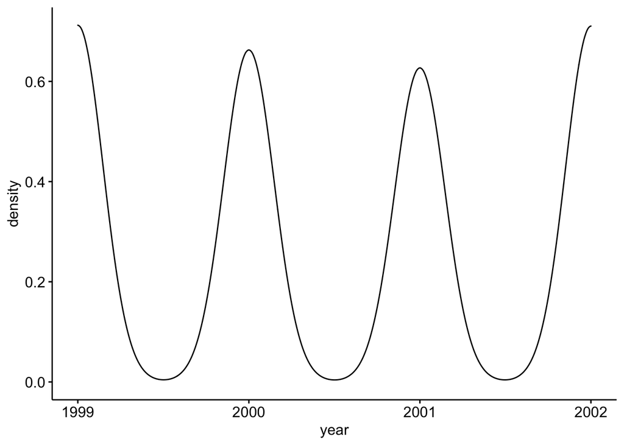

```r
# Visualization
ggdensity(data,
          x = "year",
          fill = "treated",
          palette = "jco")
```

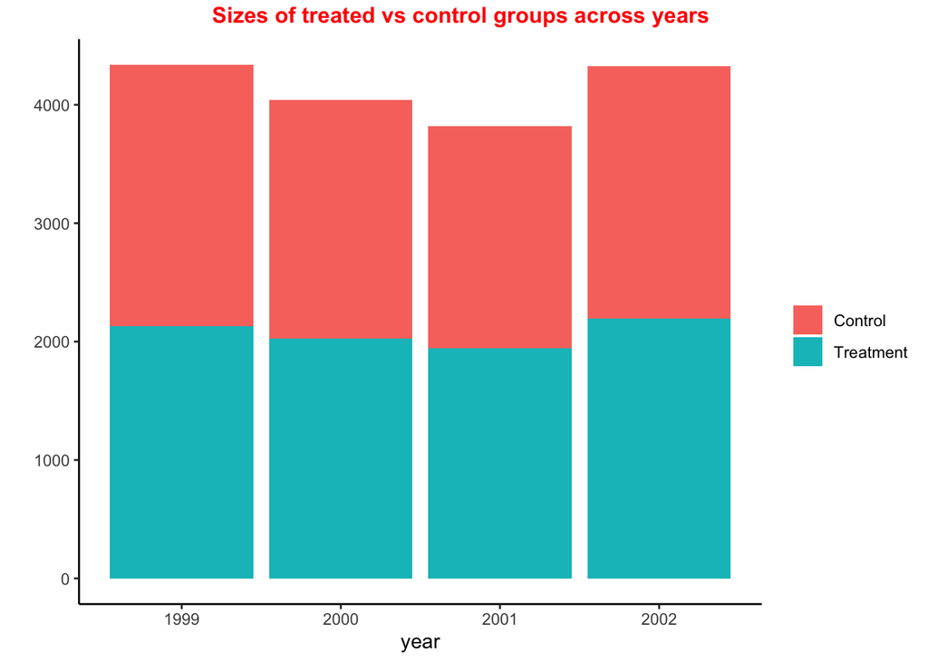

```r
p <- ggplot(data, aes(x = year,
                 y = ..count..,
                 fill = as.factor(treated))) +
  geom_bar() +
  labs(y = "") +
  guides(fill=guide_legend(title="")) +
  scale_fill_discrete(labels = c("Control","Treatment")) +
  theme_classic()


annotate_figure(p,
                top = text_grob("Sizes of treated vs control groups across years ",
                color = "red", face = "bold", size = 12))
```

We want to see if students dropped out of the research.

```r
# Gender distribution over year
data %>% group_by(boy) %>% count()
```

```
## # A tibble: 2 × 2
## # Groups:   boy [2]
##     boy     n
##   <dbl> <int>
## 1     0  8096
## 2     1  8430
```

```r
data_2001 %>% group_by(boy) %>% count()
```

```
## # A tibble: 2 × 2
## # Groups:   boy [2]
##     boy     n
##   <dbl> <int>
## 1     0  1861
## 2     1  1960
```

```r
data_2000 %>% group_by(boy) %>% count()
```

```
## # A tibble: 2 × 2
## # Groups:   boy [2]
##     boy     n
##   <dbl> <int>
## 1     0  2001
## 2     1  2038
```

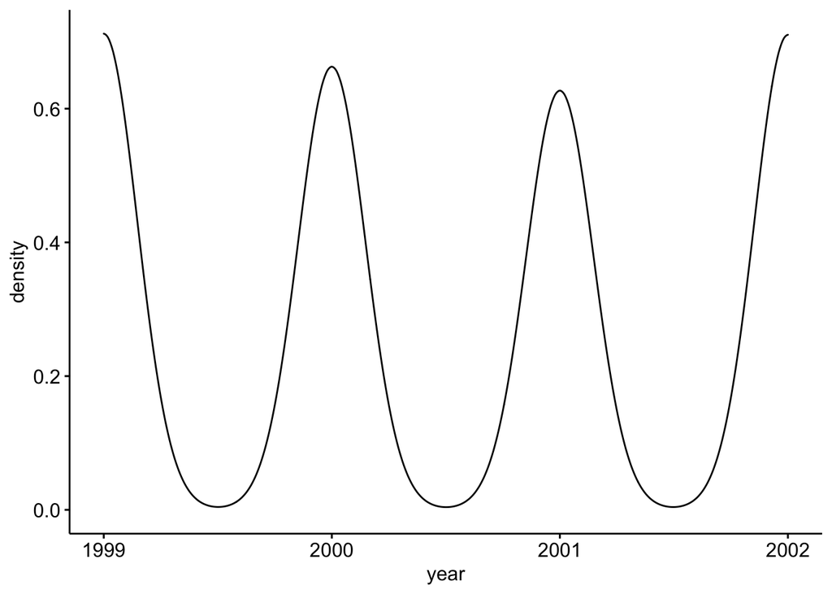

```r
# Visualization
ggdensity(data,
          x = "year",
          fill = "boy",
          palette = "jco")
```

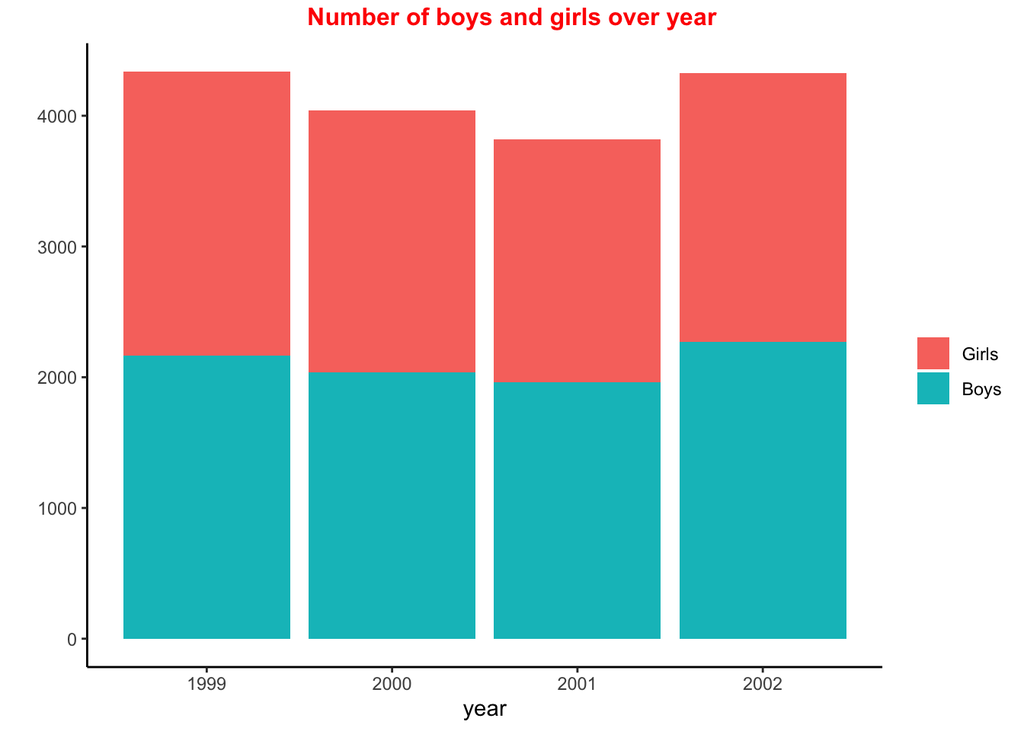

```r
p <- ggplot(data, aes(x = year,
                 y = ..count..,
                 fill = as.factor(boy))) +
  geom_bar() +
  labs(y = "") +
  guides(fill=guide_legend(title="")) +
  scale_fill_discrete(labels = c("Girls","Boys")) +
  theme_classic()


annotate_figure(p,
                top = text_grob("Number of boys and girls over year",
                color = "red", face = "bold", size = 12))
```

### 2.1.4 Descriptive Statistics Table

This includes the code for creating a table illustrating the means and standard errors of individual variables in the whole sample and subset samples for the year 2001 and 2000. This is a partial replication of the Table 1.

**Table 1: Panel A.2001**

```r
# dataframe to contain the means and standard errors
desc_table_01 <- data.frame(NULL)
desc_var <- c("bagrut_status", "school_arab", "school_religious",
               "father_educ", "mother_educ", "siblings", "immigrant",
               "lagscore", "siblings_4", "")

# for-loop to assign values into dataframe

  ## All observations
for(i in 1:10){

  # means of individual covariates
  mean <- mean(data_2001[[desc_var[i]]])

  # standard errors of individual covariates
  sd <- sd(data_2001[[desc_var[i]]])

  # number of observations
  obs <- nrow(data_2001)

  # assigning values to the table
  desc_table_01[i, 1] <- mean
  desc_table_01[i, 2] <- sd
  desc_table_01[10, 1] <- obs
  }

  ## Sample for boys
for (i in 1:10){

  # mean of the column
  mean <- mean(subset(data_2001, boy == 1)[[desc_var[i]]])

  # standard errors of individual covariates
  sd <- sd(subset(data_2001, boy == 1)[[desc_var[i]]])

  # number of observations
  obs <- nrow(subset(data_2001, boy == 1))

  # assigning values to the table
  desc_table_01[i, 3] <- mean
  desc_table_01[i, 4] <- sd
  desc_table_01[10, 2] <- obs
  }

  ## Sample for girls
for (i in 1:10){

    # mean of the column
  mean <- mean(subset(data_2001, boy == 1)[[desc_var[i]]])

  # standard errors of individual covariates
  sd <- sd(subset(data_2001, boy == 1)[[desc_var[i]]])

  # number of observations
  obs <- nrow(subset(data_2001, boy == 0))

  # assigning values to the table
  desc_table_01[i, 5] <- mean
  desc_table_01[i, 6] <- sd
  desc_table_01[10, 3] <- obs
  }

# Formatting

  ## Renaming columns
colnames(desc_table_01) <- c(
  "All", "Boy sample", "Girl sample")

  ## Renaming rows
rownames(desc_table_01) <- c("Bagrut rate", "Arab school", "Religious school",  "Father's education", "Mother's_education", "Number of siblings", "Immigrant",  "Lagged score", "Siblings category", "Number of observations")

  ## Round values
desc_table_01 <- round(desc_table_01, 3)

# Print the results
desc_table_01
```

```
##                             All Boy sample Girl sample     NA     NA     NA
## Bagrut rate               0.243      0.429       0.200  0.400  0.200  0.400
## Arab school               0.348      0.476       0.374  0.484  0.374  0.484
## Religious school          0.115      0.319       0.084  0.278  0.084  0.278
## Father's education       10.070      3.067       9.819  3.108  9.819  3.108
## Mother's_education       10.018      3.287       9.867  3.321  9.867  3.321
## Number of siblings        3.742      2.662       3.651  2.639  3.651  2.639
## Immigrant                 0.064      0.244       0.029  0.167  0.029  0.167
## Lagged score             53.120     29.381      52.062 29.421 52.062 29.421
## Siblings category         0.421      0.494       0.408  0.492  0.408  0.492
## Number of observations 3821.000   1960.000    1861.000     NA     NA     NA
```

**Table 1: Panel B.2000**

```r
# dataframe to contain the means and standard errors
desc_table_00 <- data.frame(NULL)
desc_var <- c("bagrut_status", "school_arab", "school_religious",
               "father_educ", "mother_educ", "siblings", "immigrant",
               "lagscore", "siblings_4", "")

# for-loop to assign values into dataframe

  ## All observations
for(i in 1:10){

  # means of individual covariates
  mean <- mean(data_2000[[desc_var[i]]])

  # standard errors of individual covariates
  sd <- sd(data_2000[[desc_var[i]]])

  # number of observations
  obs <- nrow(data_2000)

  # assigning values to the table
  desc_table_00[i, 1] <- mean
  desc_table_00[i, 2] <- sd
  desc_table_00[10, 1] <- obs
  }

  ## Sample boys
for (i in 1:10){

  # mean of the column
  mean <- mean(subset(data_2000, boy == 1)[[desc_var[i]]])

  # standard errors of individual covariates
  sd <- sd(subset(data_2000, boy == 1)[[desc_var[i]]])

  # number of observations
  obs <- nrow(subset(data_2000, boy == 1))

  # assigning values to the table
  desc_table_00[i, 3] <- mean
  desc_table_00[i, 4] <- sd
  desc_table_00[10, 2] <- obs
  }

  ## Sample for girls
for (i in 1:10){

  # mean of the column
  mean <- mean(subset(data_2000, boy == 1)[[desc_var[i]]])

  # standard errors of individual covariates
  sd <- sd(subset(data_2000, boy == 1)[[desc_var[i]]])

  # number of observations
  obs <- nrow(subset(data_2000, boy == 0))

  # assigning values to the table
  desc_table_00[i, 5] <- mean
  desc_table_00[i, 6] <- sd
  desc_table_00[10, 3] <- obs
  }

# Formatting

  ## Rename columns
colnames(desc_table_00) <- c(
  "All", "Boy sample", "Girl sample")

  ## Rename rows
rownames(desc_table_00) <- c(
  "Bagrut rate", "Arab school", "Religious school",  "Father's education",
  "Mother's_education", "Number of siblings", "Immigrant",  "Lagged score",
  "Siblings category", "Number of observations"
  )

  ## Round values
desc_table_00 <- round(desc_table_00, 3)

# Print results
desc_table_00
```

```
##                             All Boy sample Girl sample     NA     NA     NA
## Bagrut rate               0.224      0.417       0.177  0.382  0.177  0.382
## Arab school               0.319      0.466       0.352  0.478  0.352  0.478
## Religious school          0.134      0.340       0.098  0.298  0.098  0.298
## Father's education        9.871      3.074       9.749  3.147  9.749  3.147
## Mother's_education        9.798      3.256       9.705  3.326  9.705  3.326
## Number of siblings        3.682      2.466       3.531  2.337  3.531  2.337
## Immigrant                 0.074      0.261       0.039  0.194  0.039  0.194
## Lagged score             50.233     28.927      49.130 29.368 49.130 29.368
## Siblings category         0.431      0.495       0.408  0.492  0.408  0.492
## Number of observations 4039.000   2038.000    2001.000     NA     NA     NA
```

**Combined Descriptives Statistics Table**

```r
# Panel A. 2001
  ## print standard errors beside means
for (i in 1:9){
  desc_table_01[i, 1] <- paste(
    desc_table_01[i, 1], "<br>(", desc_table_01[i, 4], ")", sep = ""
    )
  desc_table_01[i, 2] <- paste(
    desc_table_01[i, 2], "<br>(", desc_table_01[i, 5], ")", sep = ""
    )
  desc_table_01[i, 3] <- paste(
    desc_table_01[i, 3], "<br>(", desc_table_01[i, 6], ")", sep = ""
    )
}
desc_table_01[, 1] <- linebreak(desc_table_01[, 1])
desc_table_01[, 2] <- linebreak(desc_table_01[, 2])
desc_table_01[, 3] <- linebreak(desc_table_01[, 3])

  ## remove columns of the standard errors
desc_table_01 <- desc_table_01[-c(4,5,6)]
desc_table_01
```

```
##                                      All         Boy sample        Girl sample
## Bagrut rate               0.243<br>(0.4)     0.429<br>(0.2)       0.2<br>(0.4)
## Arab school             0.348<br>(0.484)   0.476<br>(0.374)   0.374<br>(0.484)
## Religious school        0.115<br>(0.278)   0.319<br>(0.084)   0.084<br>(0.278)
## Father's education      10.07<br>(3.108)   3.067<br>(9.819)   9.819<br>(3.108)
## Mother's_education     10.018<br>(3.321)   3.287<br>(9.867)   9.867<br>(3.321)
## Number of siblings      3.742<br>(2.639)   2.662<br>(3.651)   3.651<br>(2.639)
## Immigrant               0.064<br>(0.167)   0.244<br>(0.029)   0.029<br>(0.167)
## Lagged score           53.12<br>(29.421) 29.381<br>(52.062) 52.062<br>(29.421)
## Siblings category       0.421<br>(0.492)   0.494<br>(0.408)   0.408<br>(0.492)
## Number of observations              3821               1960               1861
```

```r
# Panel B.2000
  ## print standard errors beside means
for (i in 1:9){
  desc_table_00[i, 1] <- paste(
    desc_table_00[i, 1], "<br>(", desc_table_00[i, 4], ")", sep = ""
    )
  desc_table_00[i, 2] <- paste(
    desc_table_00[i, 2], "<br>(", desc_table_00[i, 5], ")", sep = ""
    )
  desc_table_00[i, 3] <- paste(
    desc_table_00[i, 3], "<br>(", desc_table_00[i, 6], ")", sep = ""
    )
}
desc_table_00[, 1] <- linebreak(desc_table_00[, 1])
desc_table_00[, 2] <- linebreak(desc_table_00[, 2])
desc_table_00[, 3] <- linebreak(desc_table_00[, 3])

  ## remove columns of the standard errors
desc_table_00 <- desc_table_00[-c(4,5,6)]
desc_table_00
```

```
##                                       All        Boy sample       Girl sample
## Bagrut rate              0.224<br>(0.382)  0.417<br>(0.177)  0.177<br>(0.382)
## Arab school              0.319<br>(0.478)  0.466<br>(0.352)  0.352<br>(0.478)
## Religious school         0.134<br>(0.298)   0.34<br>(0.098)  0.098<br>(0.298)
## Father's education       9.871<br>(3.147)  3.074<br>(9.749)  9.749<br>(3.147)
## Mother's_education       9.798<br>(3.326)  3.256<br>(9.705)  9.705<br>(3.326)
## Number of siblings       3.682<br>(2.337)  2.466<br>(3.531)  3.531<br>(2.337)
## Immigrant                0.074<br>(0.194)  0.261<br>(0.039)  0.039<br>(0.194)
## Lagged score           50.233<br>(29.368) 28.927<br>(49.13) 49.13<br>(29.368)
## Siblings category        0.431<br>(0.492)  0.495<br>(0.408)  0.408<br>(0.492)
## Number of observations               4039              2038              2001
```

```r
# Merging Panel A + Panel B
desc_table <- rbind(desc_table_01, desc_table_00)


# Formating & Saving

  ## Renaming rows
rownames(desc_table) <- c("Bagrut rate", "Arab school", "Religious school",
                          "Father's education", "Mother's education",
                          "Number of siblings", "Immigrant",  "Lagged score",
                          "Siblings category", "Number of observations",
                          "Bagrut rate ", "Arab school ", "Religious school ",
                          "Father's education ", "Mother's education ",
                          "Number of siblings ", "Immigrant ",
                          "Lagged score ", "Siblings category ",
                          "Number of observations ")

  ## Adding headlines
desc_table %>%
    kable(
      format = "html",
      size = 14,
      escape = FALSE,
      caption = "<b>Table 2: Descriptive Statistics</b>",
      align = "c") %>%
    kable_classic(
      full_width = F,
      html_font = "Times New Roman",
      position = "left"
      ) %>%

   # For Panel A
    pack_rows(
      "Panel A. 2001", 1, 2, italic = TRUE, bold = FALSE, underline = TRUE
      ) %>%
    pack_rows("School covariates", 2, 3, bold = TRUE) %>%
    pack_rows("Micro covariates", 4, 10, bold = TRUE) %>%

   # For Panel B
    pack_rows(
      "Panel B. 2000", 11, 12, italic = TRUE, bold = FALSE, underline = TRUE,
      hline_before = TRUE, hline_after = TRUE
      ) %>%
    pack_rows("School covariates", 12, 13, bold = TRUE) %>%
    pack_rows("Micro covariates", 14, 19, bold = TRUE) %>%

   # Adding footnotes for table
  footnote(general = c(
    "Table columns report sample means and standard deviations (shown in parentheses).",
    "This is a replication of Table B1 (Angrist & Lavy, 2009, p. 1391)"
    ),
    footnote_as_chunk = T
    )
```

**Table 2: Descriptive Statistics**

|  | All | Boy sample | Girl sample |
| --- | --- | --- | --- |
| *Panel A. 2001* |  |  |  |
| Bagrut rate | 0.243 (0.4) | 0.429 (0.2) | 0.2 (0.4) |
| **School covariates** |  |  |  |
| Arab school | 0.348 (0.484) | 0.476 (0.374) | 0.374 (0.484) |
| Religious school | 0.115 (0.278) | 0.319 (0.084) | 0.084 (0.278) |
| **Micro covariates** |  |  |  |
| Father’s education | 10.07 (3.108) | 3.067 (9.819) | 9.819 (3.108) |
| Mother’s education | 10.018 (3.321) | 3.287 (9.867) | 9.867 (3.321) |
| Number of siblings | 3.742 (2.639) | 2.662 (3.651) | 3.651 (2.639) |
| Immigrant | 0.064 (0.167) | 0.244 (0.029) | 0.029 (0.167) |
| Lagged score | 53.12 (29.421) | 29.381 (52.062) | 52.062 (29.421) |
| Siblings category | 0.421 (0.492) | 0.494 (0.408) | 0.408 (0.492) |
| Number of observations | 3821 | 1960 | 1861 |
| *Panel B. 2000* |  |  |  |
| Bagrut rate | 0.224 (0.382) | 0.417 (0.177) | 0.177 (0.382) |
| **School covariates** |  |  |  |
| Arab school | 0.319 (0.478) | 0.466 (0.352) | 0.352 (0.478) |
| Religious school | 0.134 (0.298) | 0.34 (0.098) | 0.098 (0.298) |
| **Micro covariates** |  |  |  |
| Father’s education | 9.871 (3.147) | 3.074 (9.749) | 9.749 (3.147) |
| Mother’s education | 9.798 (3.326) | 3.256 (9.705) | 9.705 (3.326) |
| Number of siblings | 3.682 (2.337) | 2.466 (3.531) | 3.531 (2.337) |
| Immigrant | 0.074 (0.194) | 0.261 (0.039) | 0.039 (0.194) |
| Lagged score | 50.233 (29.368) | 28.927 (49.13) | 49.13 (29.368) |
| Siblings category | 0.431 (0.492) | 0.495 (0.408) | 0.408 (0.492) |
| Number of observations | 4039 | 2038 | 2001 |

**Conclusion:**

```
* Fewer observations are recorded in the year 2001 compared to 2000, which is due to the drop out of the 39th school. However, the difference is not significant and the size of the sample remains efficiently large.

* Number of boys and number of girls in the treatment group and control group are relatively similar and constant over year. There are no significant drop-outs.
```

## 2.2 Univariate descriptives

Data descriptive and visualization of the descriptive for each variable for all samples.

```r
# Immigration status
  # Most students are natives: 3578 compared to 243
data_2001 %>% group_by(immigrant) %>% count()
```

```
## # A tibble: 2 × 2
## # Groups:   immigrant [2]
##   immigrant     n
##       <dbl> <int>
## 1         0  3578
## 2         1   243
```

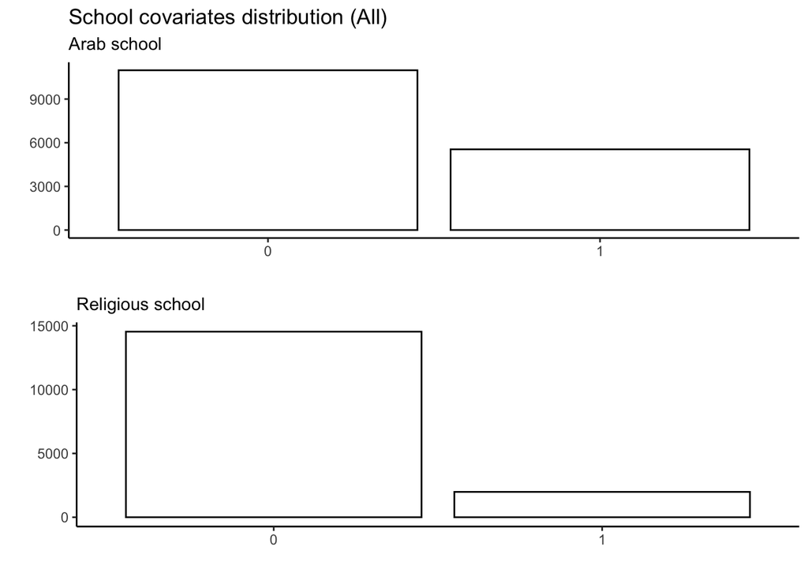

```r
# Visualization
p <- ggplot(data = data) + labs(x = "", y = "") +
    theme_classic()

# School covariates
grid.arrange(

  p +
    geom_bar(mapping = aes(factor(school_arab)),
             color="black", fill="white") +
    labs(title = "School covariates distribution (All)",
         subtitle = "Arab school"),

  p +
    geom_bar(aes(factor(school_religious)),
             color="black", fill="white") +
    labs(subtitle = "Religious school")
)
```

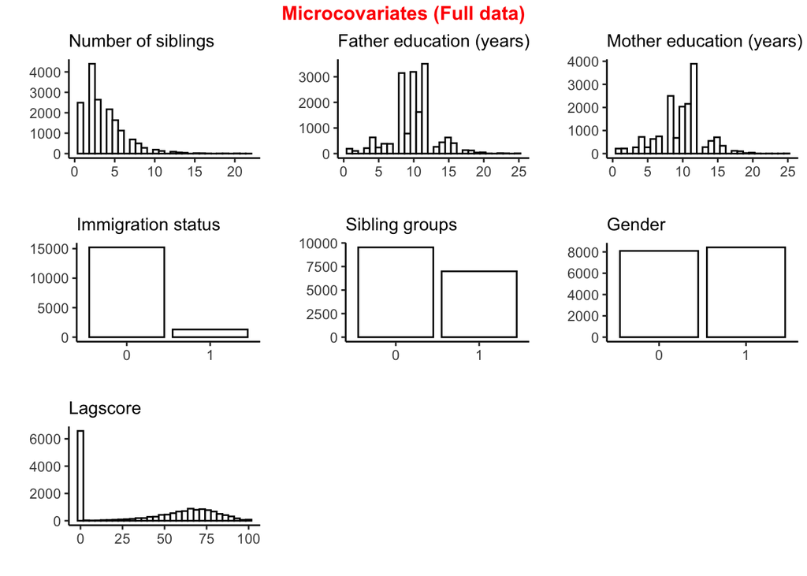

```r
# Micro-covariates
p1 <-  p +
    geom_histogram(mapping = aes(siblings),
                   color="black", fill="white") +
    labs(subtitle = "Number of siblings")

p2 <- p +
   geom_histogram(mapping = aes(father_educ),
                   color="black", fill="white") +
    labs(subtitle = "Father education (years)")

p3 <-  p +
    geom_histogram(mapping = aes(mother_educ),
                   color="black", fill="white") +
    labs(subtitle = "Mother education (years)")

p4 <- p +
    geom_bar(mapping = aes(factor(immigrant)),
             color="black", fill="white") +
    labs(subtitle = "Immigration status")

p5 <- p +
    geom_bar(mapping = aes(factor(siblings_4)),
             color="black", fill="white") +
    labs(subtitle = "Sibling groups")

p6 <- p + geom_bar(mapping = aes(factor(boy)),
                   color="black", fill="white") +
                  labs(subtitle = "Gender")
p7 <-  p +
    geom_histogram(mapping = aes(lagscore),
                   color="black", fill="white") +
    labs(subtitle = "Lagscore")

p <- ggarrange(p1, p2, p3, p4, p5, p6, p7)
annotate_figure(p,
                top = text_grob("Microcovariates (Full data)",
                color = "red", face = "bold", size = 12))
```

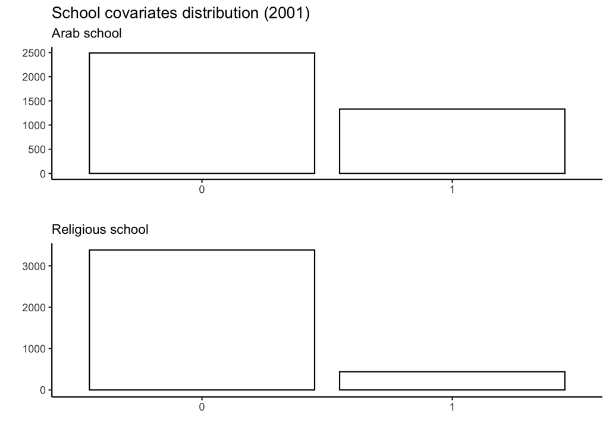

```r
# Visualization
p <- ggplot(data = data_2001) + labs(x = "", y = "") +
    theme_classic()

# School covariates
grid.arrange(

  p +
    geom_bar(mapping = aes(factor(school_arab)),
             color="black", fill="white") +
    labs(title = "School covariates distribution (2001)",
         subtitle = "Arab school"),

  p +
    geom_bar(aes(factor(school_religious)),
             color="black", fill="white") +
    labs(subtitle = "Religious school")
)
```

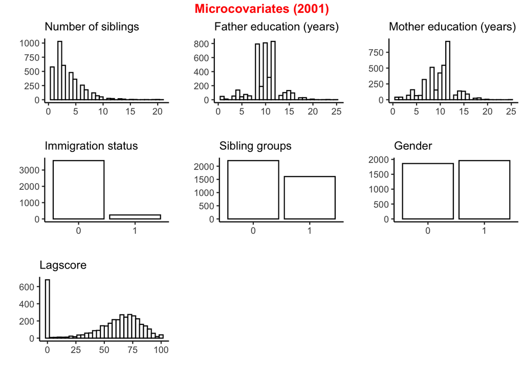

```r
# Micro-covariates
p1 <-  p +
    geom_histogram(mapping = aes(siblings),
                   color="black", fill="white") +
    labs(subtitle = "Number of siblings")

p2 <- p +
   geom_histogram(mapping = aes(father_educ),
                   color="black", fill="white") +
    labs(subtitle = "Father education (years)")

p3 <-  p +
    geom_histogram(mapping = aes(mother_educ),
                   color="black", fill="white") +
    labs(subtitle = "Mother education (years)")

p4 <- p +
    geom_bar(mapping = aes(factor(immigrant)),
             color="black", fill="white") +
    labs(subtitle = "Immigration status")

p5 <- p +
    geom_bar(mapping = aes(factor(siblings_4)),
             color="black", fill="white") +
    labs(subtitle = "Sibling groups")

p6 <- p + geom_bar(mapping = aes(factor(boy)),
                   color="black", fill="white") +
                  labs(subtitle = "Gender")
p7 <-  p +
    geom_histogram(mapping = aes(lagscore),
                   color="black", fill="white") +
    labs(subtitle = "Lagscore")

p <- ggarrange(p1, p2, p3, p4, p5, p6, p7)
annotate_figure(p,
                top = text_grob("Microcovariates (2001)",
                color = "red", face = "bold", size = 12))
```

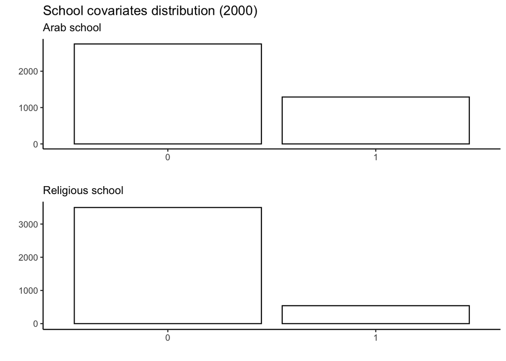

```r
# Visualization

# School covariates
p <- ggplot(data = data_2000) + labs(x = "", y = "") +
    theme(title = element_text(size=8, face="bold")) +
    theme_classic()

# School covariates
grid.arrange(
  p +
    geom_bar(mapping = aes(factor(school_arab)),
             color="black", fill="white") +
    labs(title = "School covariates distribution (2000)",
         subtitle = "Arab school"),

 p +
    geom_bar(aes(factor(school_religious)),
             color="black", fill="white") +
    labs(subtitle = "Religious school")
)
```

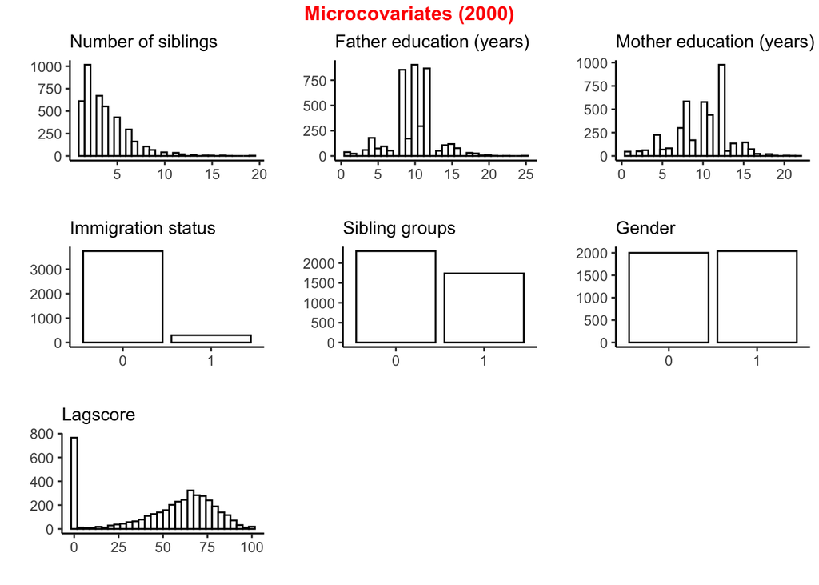

```r
# Micro-covariates
p1 <- p + geom_histogram(mapping = aes(siblings),
                         color="black", fill="white") +
                        labs(subtitle = "Number of siblings")


p2 <- p + geom_histogram(mapping = aes(father_educ),
                         color="black", fill="white") +
                        labs(subtitle = "Father education (years)")

p3 <- p + geom_histogram(mapping = aes(mother_educ),
                         color="black", fill="white") +
                        labs(subtitle = "Mother education (years)")

p4 <- p + geom_bar(mapping = aes(factor(immigrant)),
                   color="black", fill="white") +
                  labs(subtitle = "Immigration status")

p5 <- p + geom_bar(mapping = aes(factor(siblings_4)),
                   color="black", fill="white") +
                  labs(subtitle = "Sibling groups")

p6 <- p + geom_bar(mapping = aes(factor(boy)),
                   color="black", fill="white") +
                  labs(subtitle = "Gender")

p7 <- p + geom_histogram(mapping = aes(lagscore),
                   color="black", fill="white") +
                  labs(subtitle = "Lagscore")

p <- ggarrange(p1, p2, p3, p4, p5, p6, p7)
annotate_figure(p,
                top = text_grob("Microcovariates (2000)",
                color = "red", face = "bold", size = 12))
```

```r
# Gender distribution in treated vs untreated groups
data %>% group_by(boy, treated) %>% count()
```

```
## # A tibble: 4 × 3
## # Groups:   boy, treated [4]
##     boy treated     n
##   <dbl>   <dbl> <int>
## 1     0       0  4563
## 2     0       1  3533
## 3     1       0  3670
## 4     1       1  4760
```

## 2.3 Multivariate descriptives (Data 2001)

This part specifically looks at the relationships between multivariate variables in the sample of interest, **data_2001**.

**School covariates**

```r
# Sibling categories in Arab and Religious school
data_2001 %>% group_by(school_arab, siblings_4) %>% count()
```

```
## # A tibble: 4 × 3
## # Groups:   school_arab, siblings_4 [4]
##   school_arab siblings_4     n
##         <dbl>      <dbl> <int>
## 1           0          0  1984
## 2           0          1   507
## 3           1          0   229
## 4           1          1  1101
```

```r
data_2001 %>% group_by(school_religious, siblings_4) %>% count()
```

```
## # A tibble: 4 × 3
## # Groups:   school_religious, siblings_4 [4]
##   school_religious siblings_4     n
##              <dbl>      <dbl> <int>
## 1                0          0  1974
## 2                0          1  1407
## 3                1          0   239
## 4                1          1   201
```

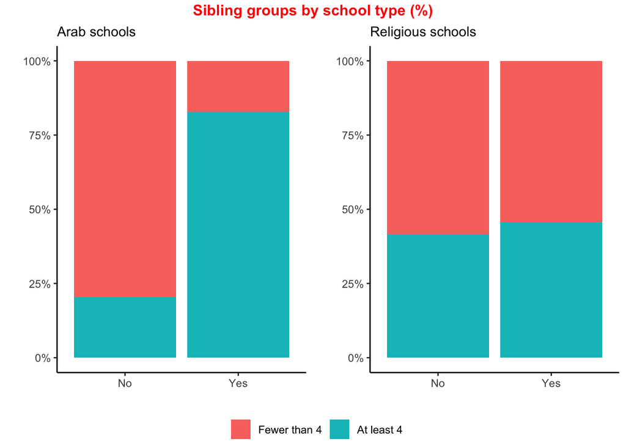

```r
p <- ggplot(data = data_2001) +
  scale_y_continuous(labels = scales::percent) +
  scale_x_discrete(labels=c("0" = "No", "1" = "Yes")) +
  guides(fill=guide_legend(title="")) +
  scale_fill_discrete(labels = c("Fewer than 4","At least 4")) +
  theme_classic()

# Different graphs for 2 school types
p1 <- p + geom_bar(aes(x = factor(school_arab),
                   y = ..count.. / sum(..count..),
                   fill = factor(siblings_4)),
                   position="fill") +
      labs(x = "",
           y = "",
           subtitle = "Arab schools")

p2 <- p + geom_bar(aes(x = factor(school_religious),
                   y = ..count.. / sum(..count..),
                   fill = factor(siblings_4)),
              position="fill") +
      labs(subtitle = "Religious schools",
           x = "",
           y = "")

p <- ggarrange(p1, p2, common.legend = T, legend="bottom")

annotate_figure(p,
                top = text_grob("Sibling groups by school type (%)",
                color = "red", face = "bold", size = 12))
```

**Micro covariates**

```r
# Schooling of mother and father in 2 sibling categories
data_2001 %>% group_by(father_educ, siblings_4) %>% count()
```

```
## # A tibble: 44 × 3
## # Groups:   father_educ, siblings_4 [44]
##    father_educ siblings_4     n
##          <dbl>      <dbl> <int>
##  1           1          0    35
##  2           1          1    12
##  3           2          0     1
##  4           2          1     9
##  5           3          0    12
##  6           3          1    40
##  7           4          0    18
##  8           4          1   120
##  9           5          0     4
## 10           5          1    38
## # … with 34 more rows
```

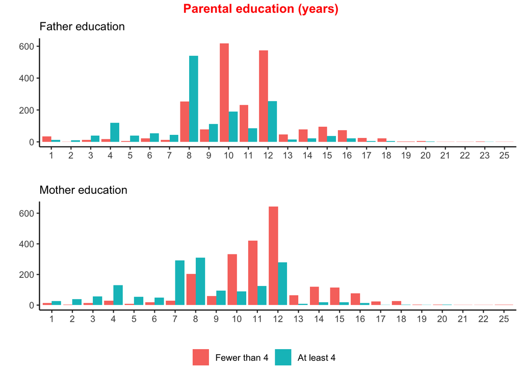

```r
# Visualization
# Comparing school levels of mother and father between 2 sibling groups
p1 <- ggplot(data = data_2001,
       aes(x = factor(father_educ),
           y = ..count..,
           fill = factor(siblings_4))) +
  geom_bar(position = "dodge" ) +
  labs(subtitle = "Father education",
       x = "", y = "") +
  guides(fill=guide_legend(title="")) +
  scale_fill_discrete(labels = c("Fewer than 4","At least 4")) +
  theme_classic()

p2 <- ggplot(data = data_2001,
       aes(x = factor(mother_educ),
           y = ..count..,
           fill = factor(siblings_4))) +
  geom_bar(position = "dodge" ) +
  labs(subtitle = "Mother education",
       x = "", y = "") +
  theme_classic()

p <- ggarrange(p1, p2, common.legend = T, legend="bottom", nrow = 2)

annotate_figure(p,
                top = text_grob("Parental education (years)",
                color = "red", face = "bold", size = 12))
```

```r
# Sibling categories between immigrants and natives
data_2001 %>% group_by(immigrant, siblings_4) %>% count()
```

```
## # A tibble: 4 × 3
## # Groups:   immigrant, siblings_4 [4]
##   immigrant siblings_4     n
##       <dbl>      <dbl> <int>
## 1         0          0  2030
## 2         0          1  1548
## 3         1          0   183
## 4         1          1    60
```

[figure not shown]

```r
# Visualization
p <- ggplot(data = data_2001,
       aes(x = factor(immigrant),
           y = ..count.. / sum(..count..),
           fill = factor(siblings_4))) +
  geom_bar(position="fill") +
  labs(x = "",
       y = "") +
  scale_y_continuous(labels = scales::percent) +
  guides(fill=guide_legend(title="")) +
  scale_fill_discrete(labels = c("Fewer than 4","At least 4")) +
  scale_x_discrete(labels=c("0" = "Girls", "1" = "Boys")) +
  theme(legend.position="bottom") +
  theme_classic()

annotate_figure(p,
                top = text_grob("Family size of immigrants and natives",
                color = "red", face = "bold", size = 12))
```

```r
# Gender distribution in 2 siblings categories
data_2001 %>% group_by(boy, siblings_4) %>% count()
```

```
## # A tibble: 4 × 3
## # Groups:   boy, siblings_4 [4]
##     boy siblings_4     n
##   <dbl>      <dbl> <int>
## 1     0          0  1053
## 2     0          1   808
## 3     1          0  1160
## 4     1          1   800
```

```r
data_2001 %>% group_by(boy) %>% count()
```

```
## # A tibble: 2 × 2
## # Groups:   boy [2]
##     boy     n
##   <dbl> <int>
## 1     0  1861
## 2     1  1960
```

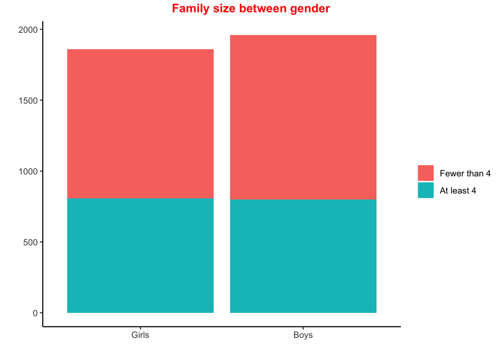

```r
# Visualization
p <- ggplot(data_2001,
       aes(x = factor(boy),
           y = ..count..,
           fill = factor(siblings_4))) +
  geom_bar() +
  labs(x = "",
       y = "") +
  guides(fill=guide_legend(title="")) +
  scale_fill_discrete(labels = c("Fewer than 4","At least 4")) +
  scale_x_discrete(labels=c("0" = "Girls", "1" = "Boys")) +
  theme_classic()

annotate_figure(p,
                top = text_grob("Family size between gender",
                color = "red", face = "bold", size = 12))
```

Students with at least 4 siblings have lower lagscore performance. However, this can be due to the size of the two sibling categories - there are more observations for the group that has fewer siblings.

```r
# Lagscore distribution in 2 siblings groups
list ("fewer than 4 siblings" = with(data_2001 %>%
                                       filter(siblings_4 == 0),
                                     summary(lagscore)),

      "at least 4 siblings" = with(data_2001 %>%
                               filter(siblings_4 == 1),
                               summary(lagscore)))
```

```
## $`fewer than 4 siblings`
##    Min. 1st Qu.  Median    Mean 3rd Qu.    Max.
##    0.00   45.00   63.33   55.79   75.33  100.00
##
## $`at least 4 siblings`
##    Min. 1st Qu.  Median    Mean 3rd Qu.    Max.
##    0.00   19.00   59.50   49.45   73.88  100.00
```

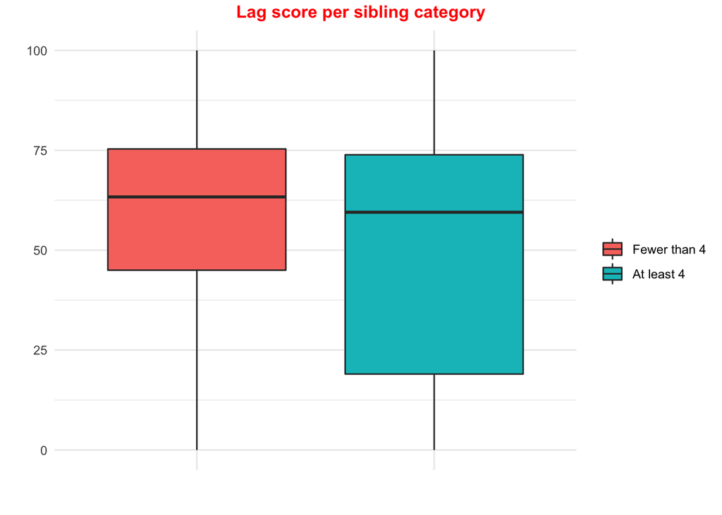

```r
# Visualization
p <- ggplot(data_2001,
       aes(x = factor(siblings_4), y = lagscore,
           fill = factor(siblings_4))) +
  geom_boxplot() +
  labs(x = "",
       y = "") +
  guides(fill=guide_legend(title="")) +
  scale_fill_discrete(labels = c("Fewer than 4","At least 4")) +
  scale_x_discrete(labels=c("0" = "", "1" = "")) +
  theme_minimal()

annotate_figure(p,
                top = text_grob("Lag score per sibling category",
                color = "red", face = "bold", size = 12))
```

**Correlation Matrices**

We draw correlation matrices for all numeric variables in the data_2001. A correlation plot of variables used for the regression in **Table 2: Panel_2001** and several correlation suplots are the provided to describe the relationship between school covariates and micro covariates to the outcome variable.

We observe that:

```
* Moderately negative correlations between parents' education and number of children (siblings)

* Correlation between number of siblings and bagrut status is almost 0.

* A weakly negative relation between family size and students' lagged scores.
```

```r
# Pearson correlation
cor_data_2001 <- data_2001 %>%
  mutate(sib_category = as.numeric(sib_category)) %>%
  select (-c("pair", "school_id", "year")) %>%
  cor() %>%
  round(4)
```

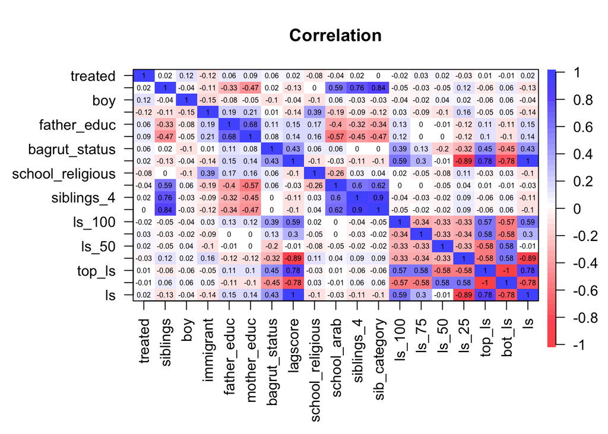

```r
# Correlation plot for all numeric variables in data_2001
corPlot(cor_data_2001,
        main = "Correlation",
        cex = 0.5,
        xlas = 2)
```

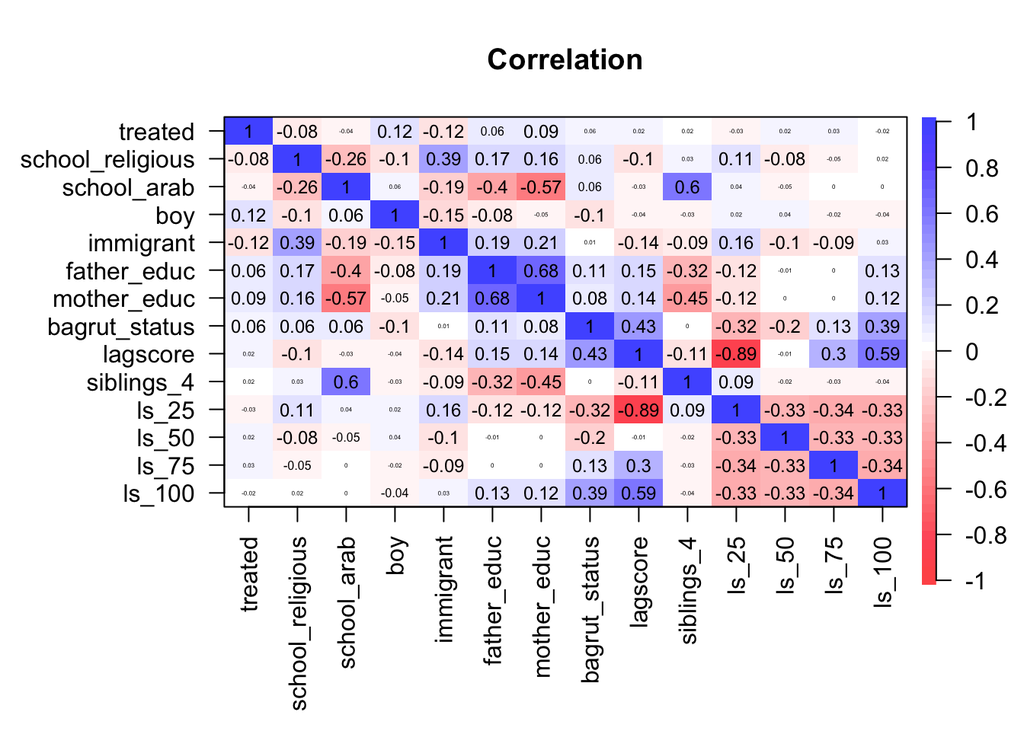

```r
# Correlation plot for variables of interest in data_2001
corPlot(data_2001 %>%
          select(treated, school_religious, school_arab,
                 boy, immigrant, father_educ, mother_educ,
                 bagrut_status, lagscore, siblings_4,
                 ls_25, ls_50, ls_75, ls_100),
        main = "Correlation",
        cex = 0.5,
        xlas = 2)
```

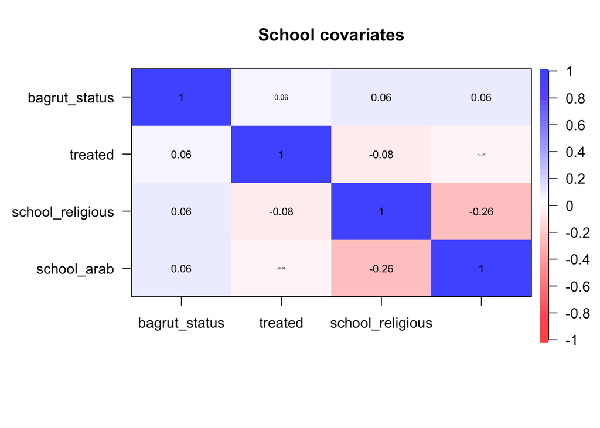

```r
# Correlation subplots

  # School covariates
corPlot(data_2001 %>%
          select(bagrut_status, treated, school_religious, school_arab),
        main = "School covariates",
        cex = 0.5)
```

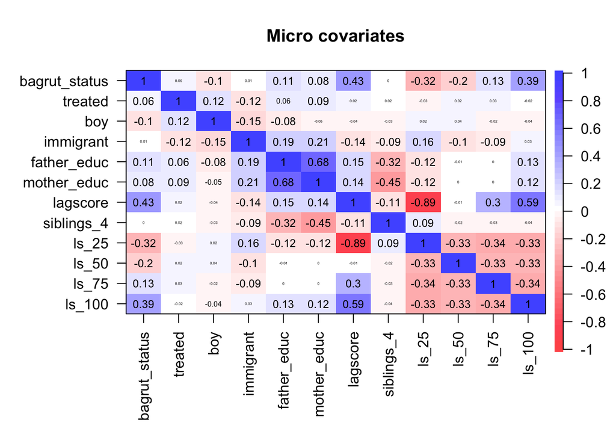

```r
  # Micro covariates
corPlot(data_2001 %>%
          select(bagrut_status, treated, boy, immigrant,
                 father_educ, mother_educ,
                 bagrut_status, lagscore, siblings_4,
                 ls_25, ls_50, ls_75, ls_100
                 ),
        main = "Micro covariates",
        cex = 0.5,
        xlas = 2)
```